# Python数据处理

## 10. UNIX/LINUX命令行

主讲人：丁平尖

## Linux的发展历史

- 1969, Bell Laboratory, UNIX
- 1984, Richard Stallman, GNU (GNU is Not Unix) and GPL (General Public License)
- 1987, Andrew S. Tanenbaum, MINIX
- 1991, Linus Torvalds, Linux内核, based on MINIX
- 1994.3, Linux 1.0 released
- 1995, Bob Young, RedHat
- 2022.8.1, Linux Kernel 5.19

## Linux不同的发行版本

[figure not shown]

## 最受欢迎Linux桌面操作系统

- 根据阿里云镜像下载统计数据：
  - 1. CentOS：CentOS是Linux发行版之一，它是来自于Red Hat Enterprise Linux依照开放源代码规定释出的源代码所编译而成。
  - 1. Ubuntu：一个完整的桌面 Linux 操作系统，免费提供比其他发行版更大的社区支持。
  - 1. Kali Linux
  - 1. Arch Linux
  - 1. Debian
  - 1. Deepin （深度）
  - 1. Linux Kylin （优麒麟）
  - 1. Fedora
  - 1. Manjaro
  - 1. OpenSUSE

## Linux系统的特点

- 命令行操作方式
- 自由软件
- 安全性高
- 多任务多用户
- 性能强大
- 网络支持好
- 扩展性好

## Linux系统安装

- 完整安装
  - 性能好；但需要重新分区，安装复杂，使用不便。
- 虚拟机安装
  - VMware，Virtual Box，Virtual PC
  - 不影响原系统；但性能较差，使用不太方便。
- Windows 10/11 内置Linux子系统（WSL）
  - 安装方便，不需要重新分区
  - 使用方便，可共享宿主系统的文件和网络

## Remote Development

- VS Code: Remote Development
  - https://code.visualstudio.com/docs/remote/remote-overview

[figure not shown]

## Remote Development

- Pycharm: GateWay
  - https://www.jetbrains.com/help/pycharm/remote-development-starting-page.html#run_in_wsl_ij

[figure not shown]

## Shell

- Shell是用户与操作系统内核之间沟通的桥梁，也是Linux的脚本语言的解释器。
  - 流行的shell：bash（Bourne Again Shell）、csh（C Shell）、ksh（Korn Shell）
- Redirect：将一个程序的输出作为另一个程序的输入。

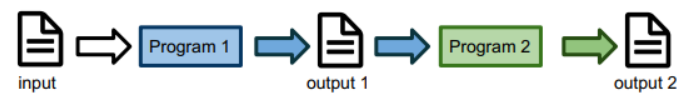

- stdin、stdout、stderr：三个特殊的“文件句柄”
  - 用于从shell读取输入（stdin）和向shell写入输出（stderr用于错误消息，stdout用于其他信息）。

## 命令行提示符的组成部分

- 用户名@主机名:当前目录 提示符/分隔符

## 连接到其他机器：ssh

- ssh（Secure Shell）网络协议允许安全通信机器
- 允许远程访问资源，例如服务器或计算集群
- `ssh user@machine`
- 服务器和客服端分别安装OpenSSH Server和OpenSSH Client

## subprocess模块

- subprocess 模块是 Python 中用于生成和管理子进程的模块，适合执行系统命令和与子进程进行交互.
- https://docs.python.org/3/library/subprocess.html
- subprocess.run：用于执行一个命令并等待其完成。适用于执行简单命令和一次性任务。
  - 运行args描述的命令。等待命令完成，然后返回一个CompletedProcess对象。
  - `subprocess.run(args， *， stdin = None， input = None， stdout = None， stderr = None， capture_output = False， shell = False， cwd = None， timeout = None， check = False， encoding = None， errors = None， text = None， env = None， universal_newlines = None， ** other_popen_kwargs)`
- CompletedProcess对象的属性
  - args: 用于启动进程的参数。可以是列表或字符串。
  - returncode: 子进程的退出状态。通常，退出状态 0 表示它已成功运行。
  - stdout: 从子进程捕获的标准输出
  - stderr: 从子进程捕获 stderr。如果未捕获 stderr，则为字节序列或字符串
  - check_returncode(): 如果returncode非零，则引发CalledProcessError。

```python
import subprocess
x = subprocess.run("pwd", shell=True)
```

```
/mnt/c/Users/ASUS/Desktop/PPT
```

```python
print(x.stdout)
x = subprocess.run("pwd", shell=True, capture_output=True)
print(x.stdout)
print(x.returncode)
```

```
None
b'/mnt/c/Users/ASUS/Desktop/PPT\n'
0
```

## Jupyter Notebook中运行shell命令

- 使用!前缀
- 使用%前缀
- 使用%%bash
  - 在一个单元格中执行多个shell命令

```python
!pwd
```

```
/mnt/c/Users/ASUS/Desktop/PPT
```

```python
%pwd
```

```
'/mnt/c/Users/ASUS/Desktop/PPT'
```

```python
%%bash
pwd
echo $SHELL
```

```
/mnt/c/Users/ASUS/Desktop/PPT
/bin/bash
```

## 基本命令用于导航

- `pwd`：打印/当前工作目录。打印你当前所在的目录。
- `ls`：列出当前目录的内容。
- `cd dirname`：将工作目录更改为dirname。
- 一些特殊的目录符号：
  - `~`：你的家目录。
    - cd ~将带你回到你的家目录。
  - `..`：当前目录以上的目录。
    - 如果你在/mnt/c/Users/ASUS/Desktop/PPT，那么cd ..将带你到/mnt/c/Users/ASUS/Desktop。

```python
subprocess.run("pwd;", shell=True)
```

```
/mnt/c/Users/ASUS/Desktop/PPT
```

```
CompletedProcess(args='pwd;', returncode=0)
```

```python
subprocess.run("cd lecture02_files; pwd;", shell=True)
```

```
/mnt/c/Users/ASUS/Desktop/PPT/lecture02_files
```

```
CompletedProcess(args='cd lecture02_files; pwd;', returncode=0)
```

```python
subprocess.run("cd lecture02_files; ls;", shell=True)
```

```
figure-html
libs
```

```
CompletedProcess(args='cd lecture02_files; ls;', returncode=0)
```

## 基本命令：`echo`

- `echo string`：将字符串打印到shell。

```python
subprocess.run("echo 'hello world!'", shell=True)
```

```
hello world!
```

```
CompletedProcess(args="echo 'hello world!'", returncode=0)
```

## 使用`>`重定向

- 如果我想将输出发送到其他地方怎么办？
- 重定向告诉shell将程序的输出从“大于”侧发送到“小于”侧的文件。这在右侧创建文件，并覆盖已存在的旧文件！

```python
subprocess.run("echo 'hello world!' > myfile.txt", shell=True)
```

```
CompletedProcess(args="echo 'hello world!' > myfile.txt", returncode=0)
```

```python
!cat myfile.txt
```

```
hello world!
```

## 基本命令：`cat`

- `cat filename`：打印文件filename的内容。
- 所以cat就像echo，但它接受文件名作为参数，而不是字符串。

```python
subprocess.run("cat myfile.txt", shell=True)
```

```
hello world!
```

```
CompletedProcess(args='cat myfile.txt', returncode=0)
```

## 文件基本命令

- `mkdir`
  - `mkdir dirname`：如果不存在，则创建一个名为dirname的新目录
- `mv`
  - `mv file1 file2`：“移动”file1到file2，覆盖file2。
  - 如果file2是一个目录，这将把file1放在那个目录里
- `cp`
  - `cp file1 file2`：类似于mv，但创建一个名为file2的file1副本
- `rm`
  - `rm filename`：删除文件filename。

```python
subprocess.run("mkdir mydir", shell=True)
```

```
CompletedProcess(args='mkdir mydir', returncode=0)
```

```python
!ls -d mydir
```

```
mydir
```

```python
subprocess.run("cp myfile.txt mydir", shell=True)
!ls -l mydir
```

```
total 0
-rwxrwxrwx 1 pingjianding pingjianding 13 Nov  4 10:13 myfile.txt
```

```python
subprocess.run("mv mydir/myfile.txt image", shell=True)
```

```
CompletedProcess(args='mv mydir/myfile.txt image', returncode=0)
```

```python
subprocess.run("cp myfile.txt mydir", shell=True)
!ls -l mydir
print("*********************************************")
subprocess.run("rm mydir/myfile.txt", shell=True)
!ls -l mydir
```

```
total 0
-rwxrwxrwx 1 pingjianding pingjianding 13 Nov  4 10:16 myfile.txt
total 0
```